# ECOBICI: EDA

Agustín Diez

—

## Librerías utilizadas

```r
library(rmdformats)
library(tidyverse)
library(tidymodels)
library(lubridate)
library(GGally)
library(dplyr)
library(esquisse)
library(ggplot2)
library(ggpubr)
library(robustbase)
library(stringr)

library(tidyr)
```

## Seteo de directorio

```r
setwd("D:\\OneDrive\\Personal\\Maestria Data Mining\\Cuatrimestre_3\\Taller de Tesis I\\Ecobici")
```

## Lectura del dataset

Se carga el dataset a continuación y una descripción de los tipos de variables que tiene el mismo

```r
ecobici_2022 = read_csv(file='.//datasets//recorridos//trips_2022.csv')
glimpse(ecobici_2022)
```

```
Rows: 2,922,805
Columns: 19
$ ...1                       <dbl> 1, 2, 3, 4, 5, 6, 7, 8, 9, 10, 11, 12, 13, 14, 15, 16, 17, 18, 19, 20, 21, 22, 23, 24, 25, 26, 27, 28, 29, 30, 31, 32, 33, 34, 35, 36, 37, 38, 39, 4…
$ X                          <dbl> 1, 2, 3, 4, 5, 6, 7, 8, 9, 10, 11, 12, 13, 14, 15, 16, 17, 18, 19, 20, 21, 22, 23, 24, 25, 26, 27, 28, 29, 30, 31, 32, 33, 34, 35, 36, 37, 38, 39, 4…
$ Id_recorrido               <chr> "13267975BAEcobici", "13268526BAEcobici", "13268400BAEcobici", "13268164BAEcobici", "13270010BAEcobici", "13269548BAEcobici", "13268959BAEcobici", "…
$ duracion_recorrido         <dbl> 2610, 545, 2061, 12748, 4337, 4243, 932, 4337, 3735, 366, 1683, 1988, 908, 616, 1519, 1203, 71, 800, 498, 1028, 3284, 2418, 2484, 8047, 2422, 394, 4…
$ fecha_origen_recorrido     <dttm> 2022-01-16 14:58:42, 2022-01-16 17:26:27, 2022-01-16 16:51:12, 2022-01-16 15:58:01, 2022-01-16 23:40:09, 2022-01-16 20:42:30, 2022-01-16 18:47:17, …
$ id_estacion_origen         <chr> "5BAEcobici", "51BAEcobici", "161BAEcobici", "210BAEcobici", "215BAEcobici", "268BAEcobici", "278BAEcobici", "368BAEcobici", "382BAEcobici", "433BAE…
$ nombre_estacion_origen     <chr> "005 - Plaza Italia", "051 - TUCUMAN", "161 - Humahuaca", "335 - General Urquiza", "113 - Guatemala", "399 - GARCIA DEL RIO", "233 - MONROE", "378 -…
$ direccion_estacion_origen  <chr> "Av. Sarmiento 2601", "Tucuman & 9 De Julio Av.", "3912 Humahuaca", "Figueroa Alcorta & Sarmiento", "Guatemala 4773", "Av. García del Río 3182", "25…
$ long_estacion_origen       <dbl> -58.42095, -58.38213, -58.41968, -58.41128, -58.42500, -58.47700, -58.46981, -58.48208, -58.47739, -58.37373, -58.41388, -58.46330, -58.44268, -58.3…
$ lat_estacion_origen        <dbl> -34.58055, -34.60148, -34.60208, -34.57216, -34.58588, -34.55030, -34.56412, -34.59807, -34.60547, -34.63770, -34.57551, -34.62884, -34.59966, -34.6…
$ fecha_destino_recorrido    <dttm> 2022-01-16 15:42:12, 2022-01-16 17:35:32, 2022-01-16 17:25:33, 2022-01-16 19:30:29, 2022-01-17 00:52:26, 2022-01-16 21:53:13, 2022-01-16 19:02:49, …
$ id_estacion_destino        <chr> "210BAEcobici", "174BAEcobici", "117BAEcobici", "382BAEcobici", "205BAEcobici", "268BAEcobici", "236BAEcobici", "368BAEcobici", "5BAEcobici", "6BAEc…
$ nombre_estacion_destino    <chr> "335 - General Urquiza", "174 - MINISTERIO DE EDUCACION", "117 - HUMBERTO 1°", "204 - Biarritz", "125 - F.J.Santamaria de Oro", "399 - GARCIA DEL RI…
$ direccion_estacion_destino <chr> "Figueroa Alcorta & Sarmiento", "Marcelo T. de Alvear & Rodriguez Peña", "Peru  1016", "Biarritz 2403", "F.J.Santamaria de Oro & Guatemala", "Av. Ga…
$ long_estacion_destino      <dbl> -58.41128, -58.39177, -58.37418, -58.47739, -58.42802, -58.47700, -58.45517, -58.48208, -58.42095, -58.36976, -58.42639, -58.43356, -58.43149, -58.3…
$ lat_estacion_destino       <dbl> -34.57216, -34.59723, -34.62010, -34.60547, -34.58332, -34.55030, -34.56216, -34.59807, -34.58055, -34.62853, -34.57742, -34.60794, -34.61984, -34.5…
$ id_usuario                 <chr> "776361BAEcobici", "776407BAEcobici", "671762BAEcobici", "776361BAEcobici", "454615BAEcobici", "200959BAEcobici", "823366BAEcobici", "826754BAEcobic…
$ modelo_bicicleta           <chr> "ICONIC", "ICONIC", "ICONIC", "ICONIC", "ICONIC", "ICONIC", "ICONIC", "ICONIC", "ICONIC", "ICONIC", "ICONIC", "ICONIC", "ICONIC", "ICONIC", "ICONIC"…
$ Género                     <chr> "FEMALE", "MALE", "FEMALE", "FEMALE", "OTHER", "OTHER", "FEMALE", "MALE", "FEMALE", "MALE", "OTHER", "FEMALE", "MALE", "MALE", "MALE", "OTHER", "FEM…
```

## EDA y descripción de variables

```r
glimpse(ecobici_2022)
```

```
Rows: 2,922,805
Columns: 19
$ ...1                       <dbl> 1, 2, 3, 4, 5, 6, 7, 8, 9, 10, 11, 12, 13, 14, 15, 16, 17, 18, 19, 20, 21, 22, 23, 24, 25, 26, 27, 28, 29, 30, 31, 32, 33, 34, 35, 36, 37, 38, 39, 4…
$ X                          <dbl> 1, 2, 3, 4, 5, 6, 7, 8, 9, 10, 11, 12, 13, 14, 15, 16, 17, 18, 19, 20, 21, 22, 23, 24, 25, 26, 27, 28, 29, 30, 31, 32, 33, 34, 35, 36, 37, 38, 39, 4…
$ Id_recorrido               <chr> "13267975BAEcobici", "13268526BAEcobici", "13268400BAEcobici", "13268164BAEcobici", "13270010BAEcobici", "13269548BAEcobici", "13268959BAEcobici", "…
$ duracion_recorrido         <dbl> 2610, 545, 2061, 12748, 4337, 4243, 932, 4337, 3735, 366, 1683, 1988, 908, 616, 1519, 1203, 71, 800, 498, 1028, 3284, 2418, 2484, 8047, 2422, 394, 4…
$ fecha_origen_recorrido     <dttm> 2022-01-16 14:58:42, 2022-01-16 17:26:27, 2022-01-16 16:51:12, 2022-01-16 15:58:01, 2022-01-16 23:40:09, 2022-01-16 20:42:30, 2022-01-16 18:47:17, …
$ id_estacion_origen         <chr> "5BAEcobici", "51BAEcobici", "161BAEcobici", "210BAEcobici", "215BAEcobici", "268BAEcobici", "278BAEcobici", "368BAEcobici", "382BAEcobici", "433BAE…
$ nombre_estacion_origen     <chr> "005 - Plaza Italia", "051 - TUCUMAN", "161 - Humahuaca", "335 - General Urquiza", "113 - Guatemala", "399 - GARCIA DEL RIO", "233 - MONROE", "378 -…
$ direccion_estacion_origen  <chr> "Av. Sarmiento 2601", "Tucuman & 9 De Julio Av.", "3912 Humahuaca", "Figueroa Alcorta & Sarmiento", "Guatemala 4773", "Av. García del Río 3182", "25…
$ long_estacion_origen       <dbl> -58.42095, -58.38213, -58.41968, -58.41128, -58.42500, -58.47700, -58.46981, -58.48208, -58.47739, -58.37373, -58.41388, -58.46330, -58.44268, -58.3…
$ lat_estacion_origen        <dbl> -34.58055, -34.60148, -34.60208, -34.57216, -34.58588, -34.55030, -34.56412, -34.59807, -34.60547, -34.63770, -34.57551, -34.62884, -34.59966, -34.6…
$ fecha_destino_recorrido    <dttm> 2022-01-16 15:42:12, 2022-01-16 17:35:32, 2022-01-16 17:25:33, 2022-01-16 19:30:29, 2022-01-17 00:52:26, 2022-01-16 21:53:13, 2022-01-16 19:02:49, …
$ id_estacion_destino        <chr> "210BAEcobici", "174BAEcobici", "117BAEcobici", "382BAEcobici", "205BAEcobici", "268BAEcobici", "236BAEcobici", "368BAEcobici", "5BAEcobici", "6BAEc…
$ nombre_estacion_destino    <chr> "335 - General Urquiza", "174 - MINISTERIO DE EDUCACION", "117 - HUMBERTO 1°", "204 - Biarritz", "125 - F.J.Santamaria de Oro", "399 - GARCIA DEL RI…
$ direccion_estacion_destino <chr> "Figueroa Alcorta & Sarmiento", "Marcelo T. de Alvear & Rodriguez Peña", "Peru  1016", "Biarritz 2403", "F.J.Santamaria de Oro & Guatemala", "Av. Ga…
$ long_estacion_destino      <dbl> -58.41128, -58.39177, -58.37418, -58.47739, -58.42802, -58.47700, -58.45517, -58.48208, -58.42095, -58.36976, -58.42639, -58.43356, -58.43149, -58.3…
$ lat_estacion_destino       <dbl> -34.57216, -34.59723, -34.62010, -34.60547, -34.58332, -34.55030, -34.56216, -34.59807, -34.58055, -34.62853, -34.57742, -34.60794, -34.61984, -34.5…
$ id_usuario                 <chr> "776361BAEcobici", "776407BAEcobici", "671762BAEcobici", "776361BAEcobici", "454615BAEcobici", "200959BAEcobici", "823366BAEcobici", "826754BAEcobic…
$ modelo_bicicleta           <chr> "ICONIC", "ICONIC", "ICONIC", "ICONIC", "ICONIC", "ICONIC", "ICONIC", "ICONIC", "ICONIC", "ICONIC", "ICONIC", "ICONIC", "ICONIC", "ICONIC", "ICONIC"…
$ Género                     <chr> "FEMALE", "MALE", "FEMALE", "FEMALE", "OTHER", "OTHER", "FEMALE", "MALE", "FEMALE", "MALE", "OTHER", "FEMALE", "MALE", "MALE", "MALE", "OTHER", "FEM…
```

```r
df=ecobici_2022
```

### Id_recorrido

Se distingue un número, y luego el BAEcobici en todos los registros. Chequear si son únicos

```r
unique(df['Id_recorrido'])
```

| Id_recorrido |
| --- |
| 13267975BAEcobici |
| 13268526BAEcobici |
| 13268400BAEcobici |
| 13268164BAEcobici |
| 13270010BAEcobici |
| 13269548BAEcobici |
| 13268959BAEcobici |
| 13267669BAEcobici |
| 13267592BAEcobici |
| 13376812BAEcobici |

[output cut: 990 more lines]

```r
#Hago extracción del BAEcobici para chequear que todos terminan igual

df <- df %>% mutate(Id_recorrido = str_sub(Id_recorrido,0,8),
                    id_usuario = gsub("BAEcobici","",id_usuario))
```

### id_usuario

```r
# Cuento la cantidad de usuarios que usaron el sistema este año

num_usuarios <- nrow(unique(df['id_usuario']))
paste0('La cantidad de usuarios que usaron el sistema es ',num_usuarios)
```

```
[1] "La cantidad de usuarios que usaron el sistema es 204403"
```

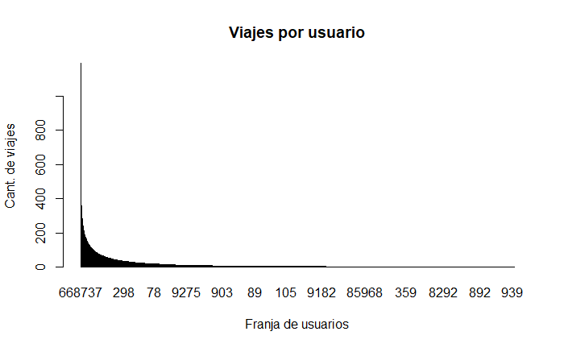

```r
cant_veces <- table(df$id_usuario)

cant_veces_sort <- sort(cant_veces,decreasing=TRUE)

barplot(cant_veces_sort,
        main = 'Viajes por usuario',
        xlab = 'Franja de usuarios',
        ylab = 'Cant. de viajes',
        breaks = 15
        )
```

```r
NA
NA
NA
```

```r
filter(df,id_usuario == "939675")
```

| ...1 | X | Id_recorrido | duracion_recorrido | fecha_origen_recorrido | id_estacion_origen | nombre_estacion_origen | direccion_estacion_origen | long_estacion_origen | lat_estacion_origen | fecha_destino_recorrido | id_estacion_destino | nombre_estacion_destino | direccion_estacion_destino | long_estacion_destino | lat_estacion_destino | id_usuario | modelo_bicicleta | Género |
| --- | --- | --- | --- | --- | --- | --- | --- | --- | --- | --- | --- | --- | --- | --- | --- | --- | --- | --- |
| 2921669 | 2921669 | 16796740 | 504 | 2022-12-31 11:39:13 | 324BAEcobici | 280 - JURAMENTO | 5209 Juramento | -58.48406 | -34.57893 | 2022-12-31 11:47:37 | 324BAEcobici | 280 - JURAMENTO | 5209 Juramento | -58.48406 | -34.57893 | 939675 | FIT | FEMALE |

### Creación de dataframe de usuarios

```r
df_usuarios <- data.frame(id_usuario = names(cant_veces_sort),
                          viajes_anuales = as.numeric(cant_veces_sort))
```

```r
boxplot(cant_veces_sort)
```

[output not shown]

### Variables asociadas a fechas

#### fecha_origen_recorrido; fecha_destino_recorrido

```r
df <- df %>% mutate(dia_origen_fecha = format(fecha_origen_recorrido, "%Y-%m-%d"),
              dia_origen=day(fecha_origen_recorrido),
              mes_origen=month(fecha_origen_recorrido),
              dia_semana_origen = wday(fecha_origen_recorrido), #1 es domingo, #2 a #6 es dia de semana, #7 es sabado
              hora_origen = hour(fecha_origen_recorrido),
              minuto_origen = minute(fecha_origen_recorrido),
              .after = fecha_origen_recorrido)


df <- df %>% mutate(dia_destino_fecha = format(fecha_destino_recorrido, "%Y-%m-%d"),
              dia_destino=day(fecha_destino_recorrido),
              mes_destino=month(fecha_destino_recorrido),
              dia_semana_destino = wday(fecha_destino_recorrido), #1 es domingo, #2 a #6 es dia de semana, #7 es sabado
              hora_destino = hour(fecha_destino_recorrido),
              minuto_destino = minute(fecha_destino_recorrido),
              .after = fecha_destino_recorrido)
```

### Variable asociada a estaciones

```r
unique(df$nombre_estacion_destino)
```

```
  [1] "335 - General Urquiza"                     "174 - MINISTERIO DE EDUCACION"             "117 - HUMBERTO 1°"                         "204 - Biarritz"
  [5] "125 - F.J.Santamaria de Oro"               "399 - GARCIA DEL RIO"                      "254 - Plaza Rafael Hernandez"              "378 - AGRONOMIA"
  [9] "005 - Plaza Italia"                        "006 - Parque Lezama"                       "014 - Pacifico"                            "029 - Parque Centenario"
 [13] "087 - Guayaquil"                           "135 - MARCELO T. DE ALVEAR"                "152 - JULIETA LANTERI"                     "147 - Constitución"
 [17] "261 - QUINTEROS LIDORO"                    "001 - FACULTAD DE DERECHO"                 "281 - Villa Urquiza"                       "255 - BARRANCAS DE BELGRANO"
 [21] "203 - Beiro"                               "207 - PLAZA ARENALES"                      "273 - Plazoleta Colombia"                  "352 - San Jose de Flores"
 [25] "189 - POSADAS"                             "142 - Armenia y Gorriti"                   "056 - Plaza Palermo Viejo"                 "066 - Billinghurst"
 [29] "111 - MACACHA GUEMES"                      "140 - Las Casas"                           "027 - Montevideo"                          "038 - Plaza Libertad"
 [33] "334 - CENTRO DE EXPOSICIONES"              "156 - Plaza Alemania"                      "085 - AGUERO"                              "171 - Pasteur"
 [37] "116 - HOSPITAL ALEMÁN"                     "035 - INGENIERO BUTTY"                     "193 - ARENALES Y AGUERO"                   "082 - HOSPITAL ITALIANO"
 [41] "071 - CERRITO"                             "046 - Chile"                               "112 - 9 de Julio"                          "131- HOSPITAL DE CLÍNICAS"
 [45] "164 - FACULTAD DE INGENIERIA"              "100 - Plaza Gurruchaga"                    "034 - Colonia Express"                     "280 - JURAMENTO"
 [49] "277 - Coghlan"                             "083 - Paraná"                              "067 - PARQUE SARMIENTO I"                  "270 - PLAZA DEL ANGEL GRIS"
 [53] "136 - Acevedo"                             "215 - HOSPITAL ALVAREZ"                    "264 - Plaza Marcos Sastre"                 "201 - PLAZA EJERCITO DE LOS ANDES"
 [57] "133 - BEIRO Y SEGUROLA"                    "086 - SAAVEDRA"                            "162 - LARREA Y BARTOLOMÉ MITRE"            "179 - CASA SAN"
```

[output cut: 69 more lines]

En función de esto, busco crear nuevas variables: nombre de estación e ID. Hay algunas estaciones sin ID

```r
unique(df$nombre_estacion_origen)
```

```
  [1] "005 - Plaza Italia"                        "051 - TUCUMAN"                             "161 - Humahuaca"                           "335 - General Urquiza"
  [5] "113 - Guatemala"                           "399 - GARCIA DEL RIO"                      "233 - MONROE"                              "378 - AGRONOMIA"
  [9] "204 - Biarritz"                            "273 - Plazoleta Colombia"                  "044 - Ecoparque"                           "352 - San Jose de Flores"
 [13] "136 - Acevedo"                             "071 - CERRITO"                             "096 - Carlos Gardel"                       "003 - ADUANA"
 [17] "152 - JULIETA LANTERI"                     "149 - LIMA"                                "255 - BARRANCAS DE BELGRANO"               "277 - Coghlan"
 [21] "014 - Pacifico"                            "281 - Villa Urquiza"                       "203 - Beiro"                               "315 - BEIRO Y SAN MARTÍN"
 [25] "140 - Las Casas"                           "017 - Plaza Almagro"                       "027 - Montevideo"                          "066 - Billinghurst"
 [29] "085 - AGUERO"                              "107 - HOSPITAL GARRAHAN"                   "111 - MACACHA GUEMES"                      "156 - Plaza Alemania"
 [33] "189 - POSADAS"                             "193 - ARENALES Y AGUERO"                   "001 - FACULTAD DE DERECHO"                 "125 - F.J.Santamaria de Oro"
 [37] "260 - SAN MIGUEL DE GARICOITS"             "350 - Plaza Irlanda"                       "237 - Madero Office"                       "009 - Parque Las Heras"
 [41] "026 - JUANA MANSO I"                       "045 - Uruguay"                             "046 - Chile"                               "083 - Paraná"
 [45] "086 - SAAVEDRA"                            "087 - Guayaquil"                           "095 - ESMERALDA"                           "117 - HUMBERTO 1°"
 [49] "121 - YATAY"                               "131- HOSPITAL DE CLÍNICAS"                 "174 - MINISTERIO DE EDUCACION"             "147 - Constitución"
 [53] "067 - PARQUE SARMIENTO I"                  "261 - QUINTEROS LIDORO"                    "142 - Armenia y Gorriti"                   "059 - Coronel Diaz"
 [57] "160 - Godoy Cruz y Libertador"             "365 - Venancio Flores"                     "287 - Belaustegui"                         "215 - HOSPITAL ALVAREZ"
```

[output cut: 68 more lines]

```r
df <- df %>% mutate(id_estacion_origen = str_extract(df$nombre_estacion_origen,"[0-9]{3}"),
              nombre_estacion_origen = str_remove(df$nombre_estacion_origen,"[0-9]{3}"),
              #Saco el guion y el primer espacio y paso a Capital first
              nombre_estacion_origen = gsub('- ','',nombre_estacion_origen),
              nombre_estacion_origen = gsub('-','',nombre_estacion_origen),
              #Corrijo y pongo full caps en las primeras palabras
              nombre_estacion_origen = str_to_title(nombre_estacion_origen),
              .after = nombre_estacion_origen)


df <- df %>% mutate(id_estacion_destino = str_extract(df$nombre_estacion_destino,"[0-9]{3}"),
              nombre_estacion_destino = str_remove(df$nombre_estacion_destino,"[0-9]{3}"),
              #Saco el guion y el primer espacio y paso a Capital first
              nombre_estacion_destino = gsub('- ','',nombre_estacion_destino),
              nombre_estacion_destino = gsub('-','',nombre_estacion_destino),
              #Corrijo y pongo full caps en las primeras palabras
              nombre_estacion_destino = str_to_title(nombre_estacion_destino),
              .after = nombre_estacion_destino)
```

Si los datos están bien debemos ver la misma cantidad de valores unicos en las tuplas de ubicacion

```r
#

puntos_distintos_long_origen <- length(unique(df$long_estacion_origen))
puntos_distintos_lat_origen <- length(unique(df$lat_estacion_origen))

puntos_distintos_long_destino <- length(unique(df$long_estacion_destino))
puntos_distintos_lat_destino <- length(unique(df$lat_estacion_destino))
```

```r
paste('Hay (',puntos_distintos_lat_origen,puntos_distintos_long_origen,' y se visualizan',length(unique(df$nombre_estacion_origen)))
```

```
[1] "Hay ( 328 328  y se visualizan 331"
```

Filtro por estacion

```r
#Chequeo si hay duplicados
df %>%
  group_by(nombre_estacion_origen) %>%
  summarise(n_distinct(lat_estacion_origen), n_distinct(long_estacion_origen))
```

| nombre_estacion_origen | n_distinct(lat_estacion_origen) | n_distinct(long_estacion_origen) |
| --- | --- | --- |
| 25 De Mayo | 1 | 1 |
| 33 Orientales | 1 | 1 |
| 9 De Julio | 1 | 1 |
| Acevedo | 1 | 1 |
| Acuña De Figueroa | 1 | 1 |
| Aduana | 1 | 1 |
| Agronomia | 1 | 1 |
| Agronomia Ii | 1 | 1 |
| Aguero | 1 | 1 |
| Aime Painé | 1 | 1 |

[output cut: 321 more lines]

Queda validado que todas las estaciones tienen una única estación. Extraigo un .csv con la data de las estaciones de ecobici

```r
length(unique(df_estaciones$nombre_estacion_origen))
length(unique(df_estaciones$nombre_estacion_destino))
```

```r
# Find the values in 'column1' that are not present in 'column2'
missing_values <- df_estaciones$nombre_estacion_destino[!(df_estaciones$nombre_estacion_destino %in% df_estaciones$nombre_estacion_origen)]

# View the missing values
missing_values
```

```r
#Chequeo las filas con esos missing values

filter(df,nombre_estacion_destino == " Pb")
```

| ...1 | X | Id_recorrido | duracion_recorrido | fecha_origen_recorrido | dia_origen_fecha | dia_origen | mes_origen | dia_semana_origen | hora_origen | minuto_origen | horario_origen | id_estacion_origen | nombre_estacion_origen | direccion_estacion_origen | long_estacion_origen | lat_estacion_origen | fecha_destino_recorrido | dia_destino_fecha | dia_destino | mes_destino | dia_semana_destino | hora_destino | minuto_destino | horario_destino | id_estacion_destino | nombre_estacion_destino | direccion_estacion_destino | long_estacion_destino | lat_estacion_destino | … |
| --- | --- | --- | --- | --- | --- | --- | --- | --- | --- | --- | --- | --- | --- | --- | --- | --- | --- | --- | --- | --- | --- | --- | --- | --- | --- | --- | --- | --- | --- | --- |
| 1243962 | 1243962 | 14766661 | 788 | 2022-06-17 19:45:59 | 2022-06-17 | 17 | 6 | 6 | 19 | 45 | 19:45 | 254 | Plaza Rafael Hernandez | Vuelta de Obligado 2004 | -58.45517 | -34.56216 | 2022-06-17 19:59:07 | 2022-06-17 | 17 | 6 | 6 | 19 | 59 | 19:59 | 359 | Pb | Av. Libertador 7100 | -58.45657 | -34.5476 | … |

```r
filter(df,nombre_estacion_destino == " Plaza Boedo")
```

| ...1 | X | Id_recorrido | duracion_recorrido | fecha_origen_recorrido | dia_origen_fecha | dia_origen | mes_origen | dia_semana_origen | hora_origen | minuto_origen | horario_origen | id_estacion_origen | nombre_estacion_origen | direccion_estacion_origen | long_estacion_origen | lat_estacion_origen | fecha_destino_recorrido | dia_destino_fecha | dia_destino | mes_destino | dia_semana_destino | hora_destino | minuto_destino | horario_destino | id_estacion_destino | nombre_estacion_destino | direccion_estacion_destino | long_estacion_destino | lat_estacion_destino | … |
| --- | --- | --- | --- | --- | --- | --- | --- | --- | --- | --- | --- | --- | --- | --- | --- | --- | --- | --- | --- | --- | --- | --- | --- | --- | --- | --- | --- | --- | --- | --- |
| 1618300 | 1618300 | 15224329 | 939 | 2022-08-12 14:34:04 | 2022-08-12 | 12 | 8 | 6 | 14 | 34 | 14:34 | 285 | Espinosa | 1785 Espinosa | -58.45732 | -34.60394 | 2022-08-12 14:49:43 | 2022-08-12 | 12 | 8 | 6 | 14 | 49 | 14:49 | 028 | Plaza Boedo | 3310 Calvo, Carlos & Sanchez De Loria | -58.41274 | -34.62313 | … |

```r
filter(df,nombre_estacion_destino == " Segui")
```

| ...1 | X | Id_recorrido | duracion_recorrido | fecha_origen_recorrido | dia_origen_fecha | dia_origen | mes_origen | dia_semana_origen | hora_origen | minuto_origen | horario_origen | id_estacion_origen | nombre_estacion_origen | direccion_estacion_origen | long_estacion_origen | lat_estacion_origen | fecha_destino_recorrido | dia_destino_fecha | dia_destino | mes_destino | dia_semana_destino | hora_destino | minuto_destino | horario_destino | id_estacion_destino | nombre_estacion_destino | direccion_estacion_destino | long_estacion_destino | lat_estacion_destino | … |
| --- | --- | --- | --- | --- | --- | --- | --- | --- | --- | --- | --- | --- | --- | --- | --- | --- | --- | --- | --- | --- | --- | --- | --- | --- | --- | --- | --- | --- | --- | --- |
| 1348182 | 1348182 | 14822931 | 1194 | 2022-06-27 01:50:40 | 2022-06-27 | 27 | 6 | 2 | 1 | 50 | 01:50 | 100 | Plaza Gurruchaga | 1078 Gurruchaga | -58.43519 | -34.59314 | 2022-06-27 02:10:34 | 2022-06-27 | 27 | 6 | 2 | 2 | 10 | 02:10 | 208 | Segui | NICASIO OROÑO 2598 | -58.4594 | -34.59674 | … |

```r
# Son 3 registros que quedaron mal guardados. Se borran.

# Delete rows with specific values in 'column'
df <- df[!(df$nombre_estacion_destino %in% missing_values), ]
```

```r
length(unique(df$nombre_estacion_origen))
```

```
[1] 331
```

```r
length(unique(df$nombre_estacion_destino))
```

```
[1] 331
```

```r
# Creo un dataframe de estaciones. Extraigo el nombre, el ID, la latitud, la longitud

# Extract unique destinations with their IDs, latitude, and longitude
df_estaciones <- unique(df[c("nombre_estacion_origen","id_estacion_origen" ,"direccion_estacion_origen","long_estacion_origen","lat_estacion_origen")])
```

```r
#Veo si hay algun duplicado. Macacha guemes está dos veces

machaca_duplicado <- filter(df_estaciones,nombre_estacion_origen == ' Macacha Guemes')

# Está mal la dirección de uno. La correcta es Macacha Guemes
# Delete rows with specific values in 'column'
df_estaciones <- df_estaciones[!(df_estaciones$direccion_estacion_origen == "Machaca Guemes 350"), ]
```

```r
length(unique(df_estaciones$nombre_estacion_origen))
```

```
[1] 331
```

Guardo como un .csv para visualizarlo en GIS

```r
write.csv(df_estaciones, ".//Avances//lista_estaciones.csv", row.names = FALSE)
```

### duracion_recorrido

Realizo histograma para estudiar la unidad de tiempo. Se encuentra en segundos la columna. Se identifican viajes que registran tiempos muy elevados. Se estudia todos aquellos que exceden el tiempo de uso permitido

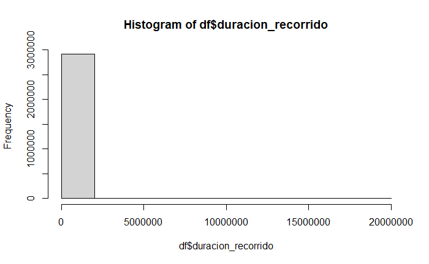

```r
hist(df$duracion_recorrido,breaks = 10)
```

Se aprecia que hay valores muy altos de duración de viajes. Los días de semana se pueden hacer viajes de hasta 60 min de manera gratuita y de 30 min los fines de semana

```r
df %>% arrange(desc(duracion_recorrido))
```

| ...1 | X | Id_recorrido | duracion_recorrido | fecha_origen_recorrido | dia_origen_fecha | dia_origen | mes_origen | dia_semana_origen | hora_origen | minuto_origen | horario_origen | id_estacion_origen | nombre_estacion_origen | direccion_estacion_origen | long_estacion_origen | lat_estacion_origen | fecha_destino_recorrido | dia_destino_fecha | dia_destino | mes_destino | dia_semana_destino | hora_destino | minuto_destino | horario_destino | id_estacion_destino | nombre_estacion_destino | direccion_estacion_destino | long_estacion_destino | lat_estacion_destino | … |
| --- | --- | --- | --- | --- | --- | --- | --- | --- | --- | --- | --- | --- | --- | --- | --- | --- | --- | --- | --- | --- | --- | --- | --- | --- | --- | --- | --- | --- | --- | --- |
| 871384 | 871384 | 14215300 | 19433313 | 2022-04-19 19:00:54 | 2022-04-19 | 19 | 4 | 3 | 19 | 0 | 19:00 | 016 | Legislatura | 169 Peru & Roca, Julio A., Presidente Diagonal Sur Av. | -58.37480 | -34.60980 | 2022-11-30 17:09:27 | 2022-11-30 | 30 | 11 | 4 | 17 | 9 | 17:09 | NA | Mantenimiento Barracas | LAFAYETTE 1730 | -58.39029 | -34.65447 | … |
| 1385131 | 1385131 | 14900640 | 5576257 | 2022-07-05 22:33:44 | 2022-07-05 | 5 | 7 | 3 | 22 | 33 | 22:33 | 269 | Plaza De La Misericordia | LAUTARO 400 | -58.45534 | -34.63170 | 2022-09-08 11:31:21 | 2022-09-08 | 8 | 9 | 5 | 11 | 31 | 11:31 | NA | Mantenimiento Barracas | LAFAYETTE 1730 | -58.39029 | -34.65447 | … |
| 2125063 | 2125063 | 15864543 | 3969265 | 2022-10-06 15:24:10 | 2022-10-06 | 6 | 10 | 5 | 15 | 24 | 15:24 | 102 | Roseti | ROSETI 390 | -58.44930 | -34.58512 | 2022-11-21 13:58:35 | 2022-11-21 | 21 | 11 | 2 | 13 | 58 | 13:58 | NA | Mantenimiento Barracas | LAFAYETTE 1730 | -58.39029 | -34.65447 | … |
| 1431414 | 1431414 | 15098087 | 3366417 | 2022-07-31 12:26:25 | 2022-07-31 | 31 | 7 | 1 | 12 | 26 | 12:26 | 074 | Instituto Leloir | Juana De Ibarbourou & Av Patricias Argentinas | -58.43454 | -34.60439 | 2022-09-08 11:33:22 | 2022-09-08 | 8 | 9 | 5 | 11 | 33 | 11:33 | NA | Mantenimiento Barracas | LAFAYETTE 1730 | -58.39029 | -34.65447 | … |
| 302843 | 302843 | 13460116 | 3010200 | 2022-02-07 18:14:44 | 2022-02-07 | 7 | 2 | 2 | 18 | 14 | 18:14 | 384 | Plaza Benito Nazar | VALENTIN VIRASORO 1349 | -58.44600 | -34.60512 | 2022-03-14 14:24:44 | 2022-03-14 | 14 | 3 | 2 | 14 | 24 | 14:24 | NA | Balboa Definitivo | 220 Balboa | -58.46578 | -34.59339 | … |
| 1129525 | 1129525 | 14572090 | 2541706 | 2022-05-26 07:10:17 | 2022-05-26 | 26 | 5 | 5 | 7 | 10 | 07:10 | 008 | Congreso | Cevallos, Virrey& Yrigoyen, Hipolito Av. | -58.38934 | -34.60942 | 2022-06-24 17:12:03 | 2022-06-24 | 24 | 6 | 6 | 17 | 12 | 17:12 | NA | Mantenimiento Barracas | LAFAYETTE 1730 | -58.39029 | -34.65447 | … |
| 1709601 | 1709601 | 15150206 | 1651995 | 2022-08-05 09:09:22 | 2022-08-05 | 5 | 8 | 6 | 9 | 9 | 09:09 | 255 | Barrancas De Belgrano | Sucre, Antonio Jose De, Mcal. Y Vertiz Virrey Av. | -58.44831 | -34.55980 | 2022-08-24 12:02:37 | 2022-08-24 | 24 | 8 | 4 | 12 | 2 | 12:02 | NA | Mantenimiento Barracas | LAFAYETTE 1730 | -58.39029 | -34.65447 | … |
| 2807522 | 2807522 | 16684158 | 1619613 | 2022-12-19 01:35:39 | 2022-12-19 | 19 | 12 | 2 | 1 | 35 | 01:35 | 083 | Paraná | 1590 Lavalle | -58.38937 | -34.60327 | 2023-01-06 19:29:12 | 2023-01-06 | 6 | 1 | 6 | 19 | 29 | 19:29 | NA | Mantenimiento Barracas | LAFAYETTE 1730 | -58.39029 | -34.65447 | … |
| 255362 | 255362 | 13646242 | 1531508 | 2022-02-24 20:53:48 | 2022-02-24 | 24 | 2 | 5 | 20 | 53 | 20:53 | 260 | San Miguel De Garicoits | Delgado & Loreto, Virrey | -58.45780 | -34.57733 | 2022-03-14 14:18:56 | 2022-03-14 | 14 | 3 | 2 | 14 | 18 | 14:18 | NA | Balboa Definitivo | 220 Balboa | -58.46578 | -34.59339 | … |
| 2432735 | 2432735 | 16303814 | 1531427 | 2022-11-12 17:44:45 | 2022-11-12 | 12 | 11 | 7 | 17 | 44 | 17:44 | 322 | Martí Y Directorio | 404 Marti, Jose | -58.47014 | -34.63641 | 2022-11-30 11:08:32 | 2022-11-30 | 30 | 11 | 4 | 11 | 8 | 11:08 | NA | Mantenimiento Barracas | LAFAYETTE 1730 | -58.39029 | -34.65447 | … |

[output cut: 990 more lines]

```r
df <- df %>% mutate(tipo_viaje = case_when(
    ((duracion_recorrido <= 3600 & dia_semana_origen %in% c(2,3,4,5,6)) | (duracion_recorrido <= 1800 & dia_semana_origen %in% c(1,7)))  ~ "GRATUITO" ,
    ((duracion_recorrido > 3600 & dia_semana_origen %in% c(2,3,4,5,6)) | (duracion_recorrido > 1800 & dia_semana_origen %in% c(1,7)))  ~ "PAGO"  ,
    (dia_semana_origen != dia_semana_destino) | (duracion_recorrido > 86400) ~ "ANORMAL"
  ))
```

Cuento cuantos viajes de cada tipo hay

```r
freq <- table(df$tipo_viaje)
```

```r
freq
```

```
GRATUITO     PAGO
 2750425   172377
```

## Extracción de dataframes finales

```r
#A fin de extraer un dataframe que sirva para identificar cada viaje, se extraen las siguientes variables:

variables_interes <- c("Id_recorrido","duracion_recorrido",
               "dia_origen_fecha","dia_semana_origen","horario_origen","id_estacion_origen","nombre_estacion_origen",
               "dia_destino_fecha","dia_semana_destino","horario_destino","id_estacion_destino","nombre_estacion_destino",
               "id_usuario","modelo_bicicleta","Género","tipo_viaje")

df_viajes <- df[variables_interes]
```

Guardo como un .csv para visualizarlo en GIS

```r
write.csv(df_viajes, ".//Avances//viajes_procesado.csv", row.names = FALSE)
```